# DSC 423: Data Analysis & Regression

## Assignment 5: Variable Screening

```
Name: Kushal Navghare
Student ID: 2116916
Honor Statement: I, Kushal Navghare, assure that I have completed this work independently.
The solutions given are entirely my own work.
```

### 1.The purpose of k-fold cross validation is often misunderstood.

#### a. How do you use cross validation to select a final (or production) model? Note: it is not the “best” of the k models you have built using cross validation.

Ans: K-Fold cross validation technique splits the data into k equal parts and considers the k-1 folds as part of training set, the remaining fold is kept aside for testing. The process builds k versions of different model and the overall accuracy metric is aggregated at the end. For each iteration, a new model is trained completely independent of the previous iteration. This way, we get to see more generalized version of the model.

However, to use this technique efficiently, we perform multiple iteration of k-fold cross validation and test multiple assumptions in such way. For example, we can try different set of features for each iteration of k-fold validation. This way, we get different performance metric for each iteration and these metrics can be compared to decide the best version of model and set of features which yields more generalized and accurate predictions on future dataset.

### 2. The pgatour2006.csv dataset contains data for 196 players. The variables in the dataset are:

- Player’s name
- PrizeMoney = average prize money per tournament
- DrivingAccuracy = percent of times a player is able to hit the fairway with his tee shot
- GIR = percent of time a player was able to hit the green within two or less than par (Greens in Regulation)
- BirdieConversion = percentage of times a player makes a birdie or better after hitting the green in regulation
- PuttingAverage = putting performance on those holes where the green was hit in regulation.
- PuttsPerRound= average number of putts per round (shots played on the green)

```r
# read file
raw_df <- read.csv(paste0(dir.path, 'data/pgatour2006.csv'))

# summary
dim(raw_df)
```

```
## [1] 196  11
```

```r
summary(raw_df)
```

```
##      Name             PrizeMoney     AveDrivingDistance DrivingAccuracy
##  Length:196         Min.   :  2240   Min.   :265.9      Min.   :49.75
##  Class :character   1st Qu.: 17369   1st Qu.:283.6      1st Qu.:59.76
##  Mode  :character   Median : 36644   Median :288.2      Median :63.24
##                     Mean   : 50891   Mean   :289.5      Mean   :63.38
##                     3rd Qu.: 57915   3rd Qu.:295.5      3rd Qu.:66.97
##                     Max.   :662771   Max.   :319.6      Max.   :78.43
##       GIR        PuttingAverage  BirdieConversion   SandSaves
##  Min.   :56.87   Min.   :1.712   Min.   :23.17    Min.   :33.91
##  1st Qu.:63.52   1st Qu.:1.763   1st Qu.:27.51    1st Qu.:45.13
##  Median :65.36   Median :1.778   Median :29.01    Median :48.66
##  Mean   :65.19   Mean   :1.780   Mean   :28.98    Mean   :48.97
##  3rd Qu.:66.77   3rd Qu.:1.796   3rd Qu.:30.55    3rd Qu.:52.87
##  Max.   :74.15   Max.   :1.851   Max.   :35.66    Max.   :63.64
##    Scrambling      BounceBack    PuttsPerRound
##  Min.   :49.02   Min.   :12.29   Min.   :27.96
##  1st Qu.:55.26   1st Qu.:17.56   1st Qu.:28.91
##  Median :57.65   Median :19.62   Median :29.19
##  Mean   :57.49   Mean   :19.60   Mean   :29.20
##  3rd Qu.:59.46   3rd Qu.:21.31   3rd Qu.:29.48
##  Max.   :66.45   Max.   :25.93   Max.   :30.19
```

```r
str(raw_df)
```

```
## 'data.frame':    196 obs. of  11 variables:
##  $ Name              : chr  "Aaron Baddeley" "Adam Scott" "Alex Aragon" "Alex Cejka" ...
##  $ PrizeMoney        : int  60661 262045 3635 17516 16683 107294 50620 57273 86782 23396 ...
##  $ AveDrivingDistance: num  288 301 303 289 288 ...
##  $ DrivingAccuracy   : num  60.7 62 51.1 66.4 63.2 ...
##  $ GIR               : num  58.3 69.1 59.1 67.7 64 ...
##  $ PuttingAverage    : num  1.75 1.77 1.79 1.78 1.76 ...
##  $ BirdieConversion  : num  31.4 30.4 29.9 29.3 29.3 ...
##  $ SandSaves         : num  54.8 53.6 37.9 45.1 52.4 ...
##  $ Scrambling        : num  59.4 57.9 50.8 54.8 57.1 ...
##  $ BounceBack        : num  19.3 19.4 16.8 17.1 18.2 ...
##  $ PuttsPerRound     : num  28 29.3 29.2 29.5 28.9 ...
```

#### a. Build a complete first-order model. Evaluate the model using 5-fold cross validation. If necessary, remove a non-significant variable and repeat until you have your final first-order model. Present the model.

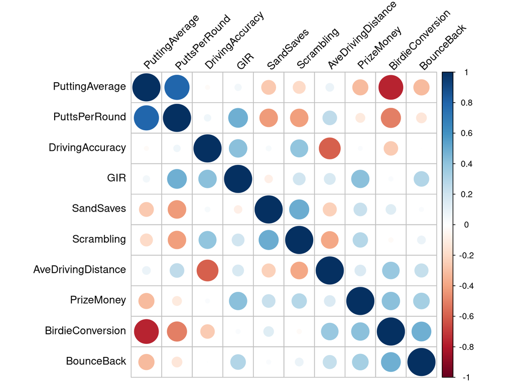

```r
# check correlation
cor_df <- cor(raw_df %>% select_if(is.numeric))

corrplot(cor_df,
         type="full",
         order="hclust",
         tl.col="black", tl.srt=45)
```

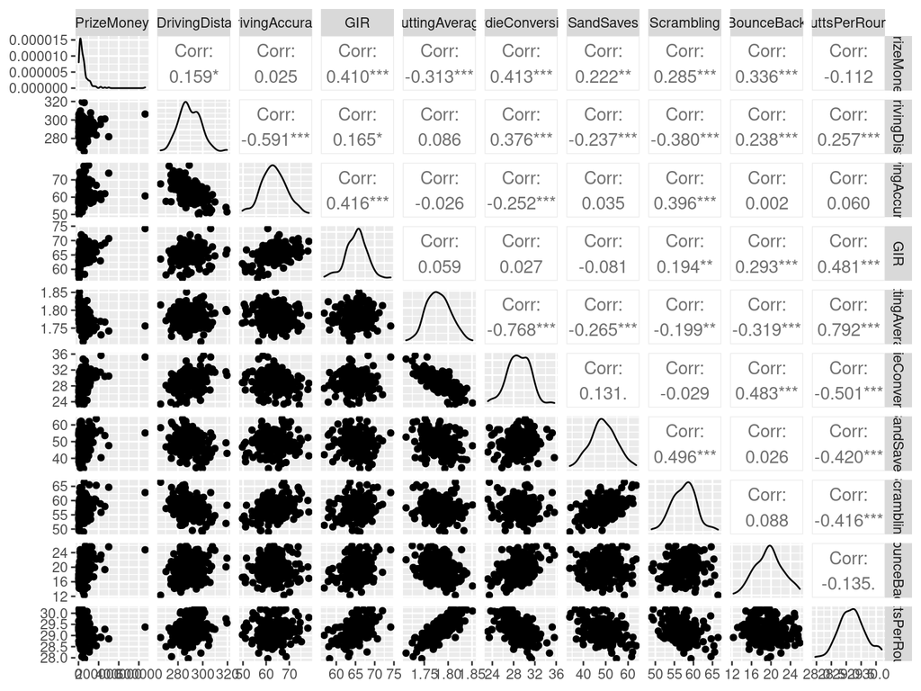

```r
# check pair plot
ggpairs(raw_df %>% select_if(is.numeric))
```

Let’s start building a first-order model. here, we will try to predict based on Player’s attributes, how much PrizeMoney can he make.

```r
# select numeric columns
num_df <- raw_df %>%
  select_if(is.numeric)

# build a model (baseline)
base_model <- lm(PrizeMoney~DrivingAccuracy+GIR+BirdieConversion+Scrambling,
                 data = num_df)

summary(base_model)
```

```
##
## Call:
## lm(formula = PrizeMoney ~ DrivingAccuracy + GIR + BirdieConversion +
##     Scrambling, data = num_df)
##
## Residuals:
##    Min     1Q Median     3Q    Max
## -85429 -27959  -7833  15674 422173
##
## Coefficients:
##                    Estimate Std. Error t value             Pr(>|t|)
## (Intercept)      -1094996.9   109585.4  -9.992 < 0.0000000000000002 ***
## DrivingAccuracy     -1964.1      815.7  -2.408                0.017 *
## GIR                  9742.9     1465.9   6.646       0.000000000306 ***
## BirdieConversion    10670.5     1703.7   6.263       0.000000002439 ***
## Scrambling           5670.4     1239.4   4.575       0.000008556442 ***
## ---
## Signif. codes:  0 '***' 0.001 '**' 0.01 '*' 0.05 '.' 0.1 ' ' 1
##
## Residual standard error: 50080 on 191 degrees of freedom
## Multiple R-squared:  0.3984, Adjusted R-squared:  0.3858
## F-statistic: 31.62 on 4 and 191 DF,  p-value: < 0.00000000000000022
```

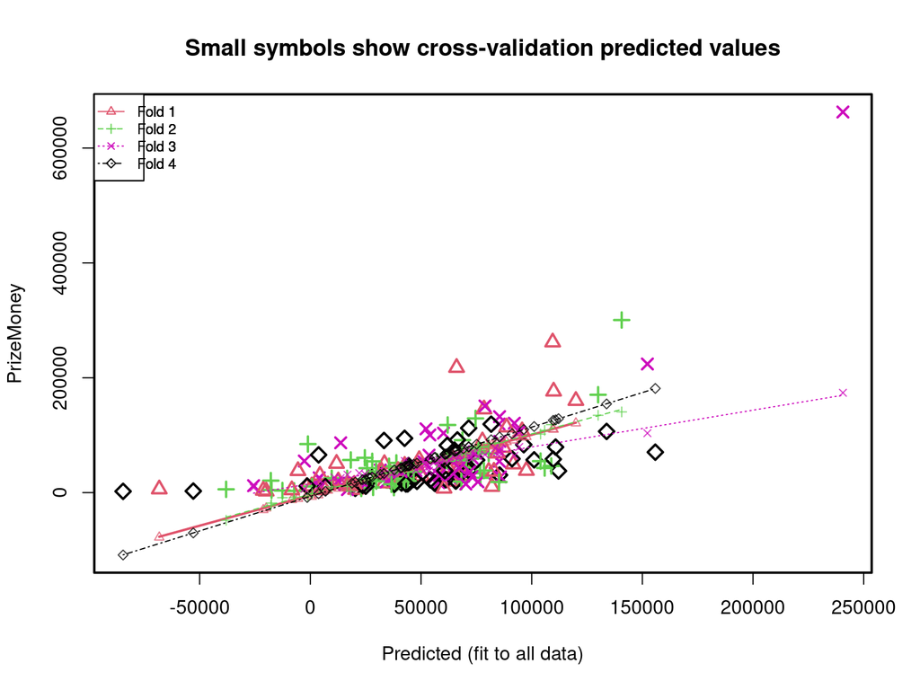

```
##
## fold 1
## Observations in test set: 49
##                    2         6        7        8        11        13        14
## Predicted   109477.3  95668.75 11848.51 49184.55  68816.83 42604.705  91689.33
## cvpred      110688.8  96458.47 12023.00 47004.96  65463.12 41791.003  91259.34
## PrizeMoney  262045.0 107294.00 50620.00 57273.00  29567.00 47172.000  49640.00
## CV residual 151356.2  10835.53 38597.00 10268.04 -35896.12  5380.997 -41619.34
##                    15        19        24        35       36        41
## Predicted    69849.63  50321.10  44308.45  97604.34 33458.09  67479.99
## cvpred       68686.54  48857.66  43583.53  97178.92 32535.57  65755.07
## PrizeMoney   53610.00  28658.00  27224.00  38455.00 50249.00  45752.00
## CV residual -15076.54 -20199.66 -16359.53 -58723.92 17713.43 -20003.07
##                    44        46        47        48        62        63
## Predicted   39605.047  33406.38  82019.24 16883.283 48247.908  66073.08
## cvpred      39856.075  29284.66  83149.91 10229.816 45768.137  63759.71
## PrizeMoney  38275.000  16630.00  10504.00 13262.000 43820.000 217748.00
## CV residual -1581.075 -12654.66 -72645.91  3032.184 -1948.137 153988.29
##                    64        65        72        77        79        81
## Predicted    3573.567 -1617.093  7933.424  80578.48 64599.621  20427.45
## cvpred      -4140.289 -4675.043  3789.004  80710.11 63335.418  15835.41
## PrizeMoney   5402.000 10528.000 13031.000  36918.00 57824.000   5265.00
## CV residual  9542.289 15203.043  9241.996 -43792.11 -5511.418 -10570.41
##                    86        88        93       101        105       108
## Predicted    62302.36  64624.61  82942.71 -19957.12  4329.9761 32159.220
## cvpred       61080.49  64835.00  82234.90 -27103.69   676.1089 32321.177
## PrizeMoney   43173.00  19594.00  37004.00   2426.00 30068.0000 37214.000
## CV residual -17907.49 -45241.00 -45230.90  29529.69 29391.8911  4892.823
##                   109       117        121       125       129        141
## Predicted    41437.30 109904.41   612.1707  60387.66 87301.233  -5594.059
## cvpred       40960.96 109999.73 -6875.2049  58143.74 87369.157 -10503.217
## PrizeMoney   26899.00 176523.00 11315.0000   7490.00 78489.000  38046.000
## CV residual -14061.96  66523.27 18190.2049 -50653.74 -8880.157  48549.217
##                   143        151       154       166      177      179
## Predicted    78469.64  -8367.754 -21266.86  88662.92 5883.315 77740.67
## cvpred       76274.45 -12614.460 -29983.60  88358.04 1881.503 78065.00
## PrizeMoney  145414.00   4667.000   3816.00 114055.00 9062.000 89770.00
## CV residual  69139.55  17281.460  33799.60  25696.96 7180.497 11705.00
##                   181       183       184      187       188       191
## Predicted   12640.251 18148.028 -68260.06 19818.04 119957.32  84465.30
```

[output cut: 129 more lines]

```
## Predicted    81690.36 44337.06034 66430.47  60836.73 -1424.039 133847.00
## cvpred       92037.17 47113.71067 73828.37  66619.87 -8474.102 154466.12
## PrizeMoney  119240.00 47046.00000 91808.00  56305.00 11421.000 106577.00
## CV residual  27202.83   -67.71067 17979.63 -10314.87 19895.102 -47889.12
##                   175       180       182       190      193       195      196
## Predicted    43164.21  3729.020  25025.13  6840.089 23591.71  60791.44 33277.00
## cvpred       46196.38 -2005.631  22976.60  2305.937 22542.64  66954.52 33238.05
## PrizeMoney   15098.00 65783.000  11187.00 10354.000 12803.00  38043.00 90824.00
## CV residual -31098.38 67788.631 -11789.60  8048.063 -9739.64 -28911.52 57585.95
##
## Sum of squares = 95370706618    Mean square = 1946340951    n = 49
##
## Overall (Sum over all 49 folds)
##         ms
## 3011434508
```

```r
# cross validation
cv_model <- cv.lm(data = num_df,
                    form.lm = formula(PrizeMoney~DrivingAccuracy+GIR+BirdieConversion+Scrambling),
                   plotit = c("Observed", "Residual"), legend.pos = "topleft",
                   m = 4)
```

#### b. Evaluate scatterplots to determine which second-order terms should be tested. Test them using 5-fold cross validation and add them one-by-one until you arrive at a model you feel is appropriate. Present the model.

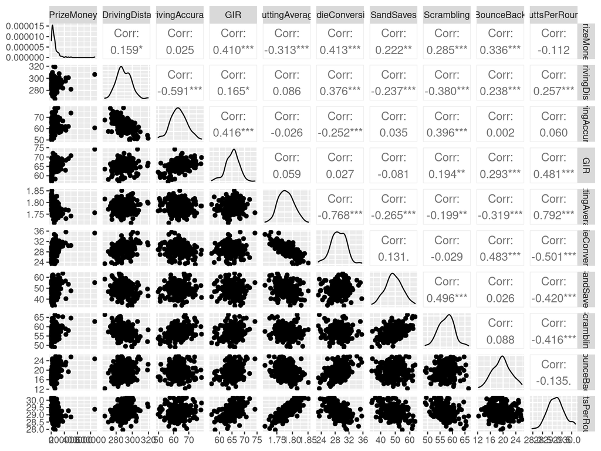

```r
# pair plot
ggpairs(num_df, size=.5)
```

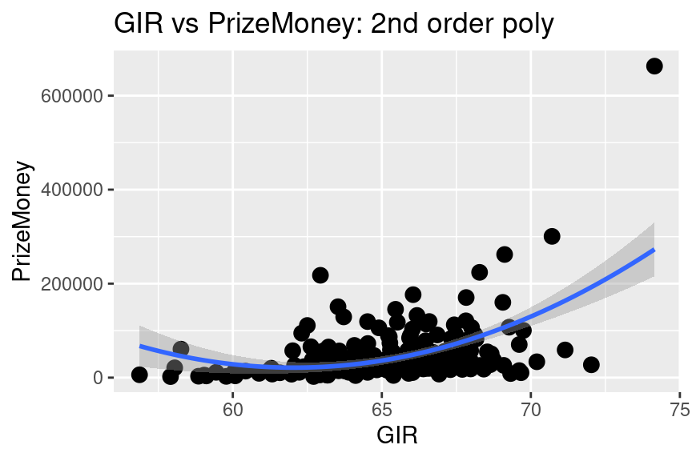

```r
# scatter plots
plt_1 <- ggplot(data = num_df, aes(x = GIR, y = PrizeMoney))
plt_1 + geom_point(size=3) +
  geom_smooth(method = "lm", formula = y ~ poly(x, 2, raw = TRUE)) +
  ggtitle("GIR vs PrizeMoney: 2nd order poly")
```

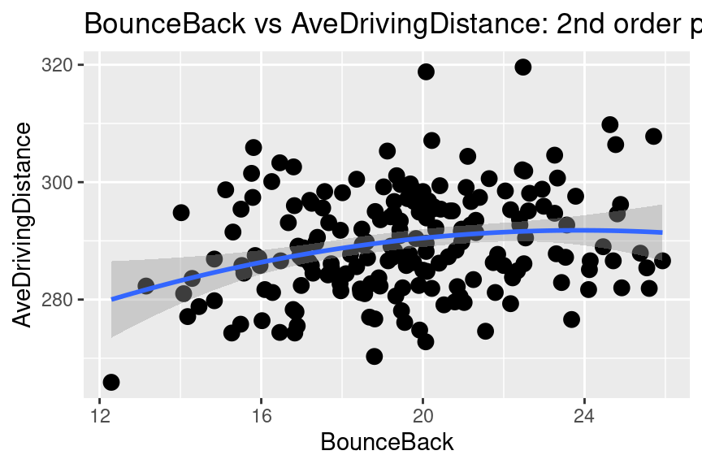

```r
plt_1 <- ggplot(data = num_df, aes(x = BounceBack, y = AveDrivingDistance))
plt_1 + geom_point(size=3) +
  geom_smooth(method = "lm", formula = y ~ poly(x, 2, raw = TRUE)) +
  ggtitle("BounceBack vs AveDrivingDistance: 2nd order poly")
```

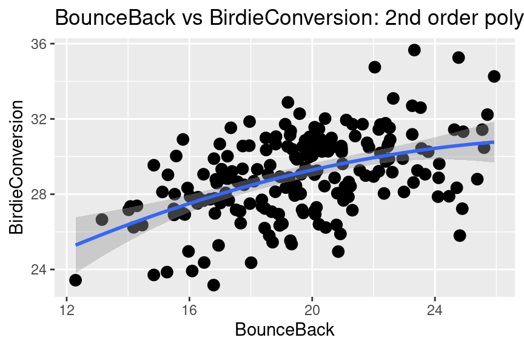

```r
plt_1 <- ggplot(data = num_df, aes(x = BounceBack, y = BirdieConversion))
plt_1 + geom_point(size=3) +
  geom_smooth(method = "lm", formula = y ~ poly(x, 2, raw = TRUE)) +
  ggtitle("BounceBack vs BirdieConversion: 2nd order poly")
```

```r
# try second order model
sec_ordr_model <- lm(PrizeMoney~(SandSaves+GIR+BirdieConversion)^2, data = num_df)

summary(sec_ordr_model)
```

```
##
## Call:
## lm(formula = PrizeMoney ~ (SandSaves + GIR + BirdieConversion)^2,
##     data = num_df)
##
## Residuals:
##     Min      1Q  Median      3Q     Max
## -131379  -21075   -6305   14861  184661
##
## Coefficients:
##                             Estimate Std. Error t value             Pr(>|t|)
## (Intercept)                8445009.3  1012279.1   8.343   0.0000000000000150
## SandSaves                   -40082.5    13989.8  -2.865             0.004640
## GIR                        -115968.5    14125.1  -8.210   0.0000000000000338
## BirdieConversion           -285772.6    30201.7  -9.462 < 0.0000000000000002
## SandSaves:GIR                  259.5      185.0   1.402             0.162445
## SandSaves:BirdieConversion     865.8      223.3   3.877             0.000146
## GIR:BirdieConversion          3891.4      415.9   9.358 < 0.0000000000000002
##
## (Intercept)                ***
## SandSaves                  **
## GIR                        ***
## BirdieConversion           ***
## SandSaves:GIR
## SandSaves:BirdieConversion ***
## GIR:BirdieConversion       ***
## ---
## Signif. codes:  0 '***' 0.001 '**' 0.01 '*' 0.05 '.' 0.1 ' ' 1
##
## Residual standard error: 41370 on 189 degrees of freedom
## Multiple R-squared:  0.5938, Adjusted R-squared:  0.5809
## F-statistic: 46.04 on 6 and 189 DF,  p-value: < 0.00000000000000022
```

```r
# add terms
sec_df <- num_df %>%
  mutate(AveDrvDistSec = AveDrivingDistance^2,
         DrvAccSec = DrivingAccuracy^2,
         GIRSec = GIR^2,
         BouncBckSec = BounceBack^2)

model_2 <- lm(PrizeMoney~BouncBckSec+GIRSec+BounceBack+BirdieConversion+GIR,
              data = sec_df)

summary(model_2)
```

```
##
## Call:
## lm(formula = PrizeMoney ~ BouncBckSec + GIRSec + BounceBack +
##     BirdieConversion + GIR, data = sec_df)
##
## Residuals:
##     Min      1Q  Median      3Q     Max
## -113508  -25116   -3667   13324  304616
##
## Coefficients:
##                   Estimate Std. Error t value       Pr(>|t|)
## (Intercept)      6290703.7  1183754.1   5.314 0.000000298288 ***
## BouncBckSec         1147.4      344.4   3.332        0.00104 **
## GIRSec              1608.6      283.6   5.672 0.000000051837 ***
## BounceBack        -44174.0    13709.9  -3.222        0.00150 **
## BirdieConversion   11596.6     1773.4   6.539 0.000000000557 ***
## GIR              -199534.9    36826.5  -5.418 0.000000180825 ***
## ---
## Signif. codes:  0 '***' 0.001 '**' 0.01 '*' 0.05 '.' 0.1 ' ' 1
##
## Residual standard error: 47140 on 190 degrees of freedom
## Multiple R-squared:  0.4699, Adjusted R-squared:  0.4559
## F-statistic: 33.68 on 5 and 190 DF,  p-value: < 0.00000000000000022
```

```r
# add interaction terms
thr_df <- sec_df %>%
  mutate(AvgDrvD_BouncBck = AveDrivingDistance*BounceBack,
         DrvAcc_GIR = DrivingAccuracy*GIR,
         PuttAvg_Gir = PuttingAverage*GIR,
         PuttAvg_BouncBck = PuttingAverage*BounceBack,
         PuttAvg_Scrmb = PuttingAverage*Scrambling,
         Scrmb_BouncBck = Scrambling*BounceBack,
         SndSvs_Scrmb = SandSaves*Scrambling) %>%
  dplyr::select(-c(Scrambling, PuttsPerRound, BounceBack))

model_3 <- lm(PrizeMoney~., data = thr_df)

summary(model_3)
```

```
##
## Call:
## lm(formula = PrizeMoney ~ ., data = thr_df)
##
## Residuals:
##     Min      1Q  Median      3Q     Max
## -132898  -19469   -1252   13954  162350
##
## Coefficients:
##                        Estimate   Std. Error t value      Pr(>|t|)
## (Intercept)        -21236344.23   6162605.32  -3.446      0.000710 ***
## AveDrivingDistance     29741.03     18419.43   1.615      0.108157
## DrivingAccuracy        52351.48     15224.66   3.439      0.000728 ***
## GIR                   121479.42     88612.67   1.371      0.172131
## PuttingAverage      12494032.77   2886857.42   4.328 0.00002506254 ***
## BirdieConversion        9052.88      2940.44   3.079      0.002408 **
## SandSaves             -11296.81      7317.91  -1.544      0.124432
## AveDrvDistSec            -59.25        32.93  -1.799      0.073680 .
## DrvAccSec                347.43       104.76   3.316      0.001105 **
## GIRSec                  1967.91       312.83   6.291 0.00000000238 ***
## BouncBckSec              611.47       320.00   1.911      0.057633 .
## AvgDrvD_BouncBck         217.77       143.47   1.518      0.130815
## DrvAcc_GIR             -1506.39       305.74  -4.927 0.00000189927 ***
## PuttAvg_Gir          -153217.47     47078.24  -3.255      0.001359 **
## PuttAvg_BouncBck      -84807.79     26861.57  -3.157      0.001871 **
## PuttAvg_Scrmb         -16577.83      5245.97  -3.160      0.001854 **
## Scrmb_BouncBck          1124.35       346.55   3.244      0.001406 **
## SndSvs_Scrmb             212.28       126.21   1.682      0.094337 .
## ---
## Signif. codes:  0 '***' 0.001 '**' 0.01 '*' 0.05 '.' 0.1 ' ' 1
##
## Residual standard error: 39130 on 178 degrees of freedom
## Multiple R-squared:  0.6578, Adjusted R-squared:  0.6251
## F-statistic: 20.12 on 17 and 178 DF,  p-value: < 0.00000000000000022
```

```r
# cross validation
cv_sec_model <- CVlm(data = thr_df,
                      form.lm = formula(PrizeMoney~.),
                      m = 4)
```

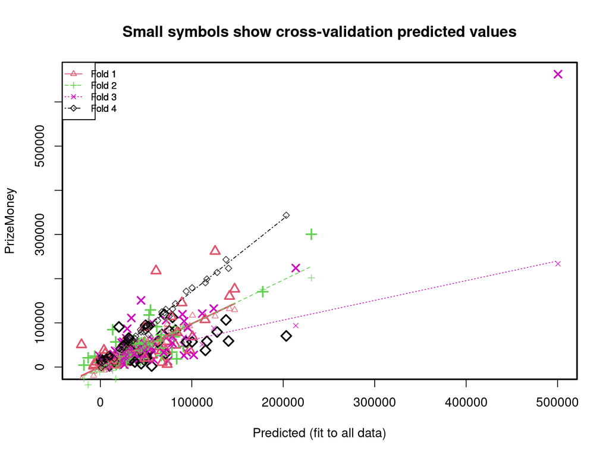

```
##
## fold 1
## Observations in test set: 49
##                    2          6         7        8       11        13        14
## Predicted   125525.9 114423.954 -20615.93 26031.22 40232.20 35070.493  82142.73
## cvpred      115000.8 113737.133 -28097.96 29458.10 35286.23 54060.569  77070.04
## PrizeMoney  262045.0 107294.000  50620.00 57273.00 29567.00 47172.000  49640.00
## CV residual 147044.2  -6443.133  78717.96 27814.90 -5719.23 -6888.569 -27430.04
##                   15        19        24        35        36        41
## Predicted   47453.28 44068.379  56970.23  97645.69 41954.907  65158.24
## cvpred      43601.67 36304.491  58455.55  92853.37 41647.658  64109.49
## PrizeMoney  53610.00 28658.000  27224.00  38455.00 50249.000  45752.00
## CV residual 10008.33 -7646.491 -31231.55 -54398.37  8601.342 -18357.49
##                    44         46        47        48       62        63
## Predicted   32356.856   535.8664  67499.17  14358.32 29923.08  60889.14
## cvpred      33206.462 -2262.0122  56530.42  27349.05 24039.38  53400.27
## PrizeMoney  38275.000 16630.0000  10504.00  13262.00 43820.00 217748.00
## CV residual  5068.538 18892.0122 -46026.42 -14087.05 19780.62 164347.73
##                     64       65        72        77        79        81
## Predicted    -7005.432  29842.5  1031.250  71895.82 72036.846  17390.88
## cvpred      -10046.184  40079.6 -4462.864  85602.14 67171.379  21238.31
## PrizeMoney    5402.000  10528.0 13031.000  36918.00 57824.000   5265.00
## CV residual  15448.184 -29551.6 17493.864 -48684.14 -9347.379 -15973.31
##                    86        88        93        101       105      108
## Predicted    51655.72  53070.12  66793.97  -7305.663  5242.526 20068.09
## cvpred       57954.25  47833.94  61091.90 -19294.576 -1960.122 12845.57
## PrizeMoney   43173.00  19594.00  37004.00   2426.000 30068.000 37214.00
## CV residual -14781.25 -28239.94 -24087.90  21720.576 32028.122 24368.43
##                   109       117       121       125       129       141
## Predicted   35370.016 146822.51  2136.900  18752.07 83830.512  3959.518
## cvpred      29086.304 129385.82  7380.533  19768.63 79810.694 -7281.394
## PrizeMoney  26899.000 176523.00 11315.000   7490.00 78489.000 38046.000
## CV residual -2187.304  47137.18  3934.467 -12278.63 -1321.694 45327.394
##                   143       151       154       166       177      179
## Predicted    89154.48 14435.659  1564.737  77737.54  9775.817 48427.42
## cvpred       89654.58 10580.604  8259.098  75069.58 18408.556 48737.12
## PrizeMoney  145414.00  4667.000  3816.000 114055.00  9062.000 89770.00
## CV residual  55759.42 -5913.604 -4443.098  38985.42 -9346.556 41032.88
##                   181        183       184       187       188       191
## Predicted    48649.53 -3926.8235  73029.20 15505.579 141227.09 100800.37
```

[output cut: 134 more lines]

```
## Predicted    1612.051 31159.834  6212.218  1739.241 15292.755  43869.35
## cvpred      17648.188 67335.474 19426.545  9059.469 18912.429  84590.00
## PrizeMoney  15098.000 65783.000 11187.000 10354.000 12803.000  38043.00
## CV residual -2550.188 -1552.474 -8239.545  1294.531 -6109.429 -46547.00
##                  196
## Predicted   20344.40
## cvpred      42001.29
## PrizeMoney  90824.00
## CV residual 48822.71
##
## Sum of squares = 286208693787    Mean square = 5840993751    n = 49
##
## Overall (Sum over all 49 folds)
##         ms
## 3677949892
```

#### c. Beginning from scratch, engineer all possible second-order terms and add them to your dataset. From this dataset, produce a model using backward selection. Evaluate this model using 5-fold cross validation. Do you arrive at the same model as above? Explain.

```r
#
part_c_df <- thr_df %>%
  mutate(gir_sec = poly(GIR, 2, raw=TRUE),
         bird_conv_sec = poly(BirdieConversion, 2, raw=T),
         sand_saves_sec = poly(SandSaves, 2, raw=T)) %>%
  dplyr::select(c(PrizeMoney, GIR, BirdieConversion, SandSaves, gir_sec, bird_conv_sec,
                  sand_saves_sec,Scrmb_BouncBck, PuttAvg_Scrmb,
                  PuttAvg_BouncBck, PuttAvg_Gir, DrvAcc_GIR, BouncBckSec))


# second order model
model_5 <- lm(PrizeMoney~.,data = part_c_df)

summary(model_5)
```

```
##
## Call:
## lm(formula = PrizeMoney ~ ., data = part_c_df)
##
## Residuals:
##     Min      1Q  Median      3Q     Max
## -125736  -20205   -2208   15527  238778
##
## Coefficients: (3 not defined because of singularities)
##                    Estimate Std. Error t value      Pr(>|t|)
## (Intercept)      6656717.34 1104322.14   6.028 0.00000000896 ***
## GIR              -176664.40   34768.66  -5.081 0.00000092100 ***
## BirdieConversion  -88272.69   26125.62  -3.379      0.000890 ***
## SandSaves          -1567.58    6645.50  -0.236      0.813785
## gir_sec1                 NA         NA      NA            NA
## gir_sec2            1152.99     274.61   4.199 0.00004186107 ***
## bird_conv_sec1           NA         NA      NA            NA
## bird_conv_sec2      1674.61     447.27   3.744      0.000242 ***
## sand_saves_sec1          NA         NA      NA            NA
## sand_saves_sec2       30.37      67.63   0.449      0.653952
## Scrmb_BouncBck      1098.05     325.08   3.378      0.000893 ***
## PuttAvg_Scrmb     -10141.07    3652.70  -2.776      0.006070 **
## PuttAvg_BouncBck  -49555.66   12607.44  -3.931      0.000120 ***
## PuttAvg_Gir        21654.82    7494.30   2.890      0.004325 **
## DrvAcc_GIR           -21.42      11.66  -1.836      0.067956 .
## BouncBckSec          643.00     309.79   2.076      0.039333 *
## ---
## Signif. codes:  0 '***' 0.001 '**' 0.01 '*' 0.05 '.' 0.1 ' ' 1
##
## Residual standard error: 42510 on 183 degrees of freedom
## Multiple R-squared:  0.5847, Adjusted R-squared:  0.5574
## F-statistic: 21.47 on 12 and 183 DF,  p-value: < 0.00000000000000022
```

Now, let’s try backward selection.

```r
# backward selection
bckwrd_selctn <- stepAIC(model_5, direction = "backward")
```

```
## Start:  AIC=4190.3
## PrizeMoney ~ GIR + BirdieConversion + SandSaves + gir_sec + bird_conv_sec +
##     sand_saves_sec + Scrmb_BouncBck + PuttAvg_Scrmb + PuttAvg_BouncBck +
##     PuttAvg_Gir + DrvAcc_GIR + BouncBckSec
##
##
## Step:  AIC=4190.3
## PrizeMoney ~ GIR + BirdieConversion + gir_sec + bird_conv_sec +
##     sand_saves_sec + Scrmb_BouncBck + PuttAvg_Scrmb + PuttAvg_BouncBck +
##     PuttAvg_Gir + DrvAcc_GIR + BouncBckSec
##
##
## Step:  AIC=4190.3
## PrizeMoney ~ GIR + gir_sec + bird_conv_sec + sand_saves_sec +
##     Scrmb_BouncBck + PuttAvg_Scrmb + PuttAvg_BouncBck + PuttAvg_Gir +
##     DrvAcc_GIR + BouncBckSec
##
##
## Step:  AIC=4190.3
## PrizeMoney ~ gir_sec + bird_conv_sec + sand_saves_sec + Scrmb_BouncBck +
##     PuttAvg_Scrmb + PuttAvg_BouncBck + PuttAvg_Gir + DrvAcc_GIR +
##     BouncBckSec
##
##                    Df   Sum of Sq          RSS    AIC
## <none>                            330726784077 4190.3
## - sand_saves_sec    2  9087838897 339814622974 4191.6
## - DrvAcc_GIR        1  6093120367 336819904444 4191.9
## - BouncBckSec       1  7785553418 338512337495 4192.9
## - PuttAvg_Scrmb     1 13930246485 344657030562 4196.4
## - PuttAvg_Gir       1 15089169972 345815954049 4197.0
## - Scrmb_BouncBck    1 20619348233 351346132310 4200.2
## - PuttAvg_BouncBck  1 27922307163 358649091240 4204.2
## - bird_conv_sec     2 44350444173 375077228250 4211.0
## - gir_sec           2 49812186522 380538970599 4213.8
```

```r
print(bckwrd_selctn$anova)
```

```
## Stepwise Model Path
## Analysis of Deviance Table
##
## Initial Model:
## PrizeMoney ~ GIR + BirdieConversion + SandSaves + gir_sec + bird_conv_sec +
##     sand_saves_sec + Scrmb_BouncBck + PuttAvg_Scrmb + PuttAvg_BouncBck +
##     PuttAvg_Gir + DrvAcc_GIR + BouncBckSec
##
## Final Model:
## PrizeMoney ~ gir_sec + bird_conv_sec + sand_saves_sec + Scrmb_BouncBck +
##     PuttAvg_Scrmb + PuttAvg_BouncBck + PuttAvg_Gir + DrvAcc_GIR +
##     BouncBckSec
##
##
##                 Step Df     Deviance Resid. Df   Resid. Dev      AIC
## 1                                          183 330726784077 4190.303
## 2        - SandSaves  0 0.0000000000       183 330726784077 4190.303
## 3 - BirdieConversion  0 0.0001220703       183 330726784077 4190.303
## 4              - GIR  0 0.0000000000       183 330726784077 4190.303
```

Let’s see how the final model is performing.

```r
model_final <- lm(PrizeMoney ~ gir_sec + bird_conv_sec + sand_saves_sec + Scrmb_BouncBck +
    PuttAvg_Scrmb + PuttAvg_BouncBck + PuttAvg_Gir + DrvAcc_GIR +
    BouncBckSec, data = part_c_df)

summary(model_final)
```

```
##
## Call:
## lm(formula = PrizeMoney ~ gir_sec + bird_conv_sec + sand_saves_sec +
##     Scrmb_BouncBck + PuttAvg_Scrmb + PuttAvg_BouncBck + PuttAvg_Gir +
##     DrvAcc_GIR + BouncBckSec, data = part_c_df)
##
## Residuals:
##     Min      1Q  Median      3Q     Max
## -125736  -20205   -2208   15527  238778
##
## Coefficients:
##                    Estimate Std. Error t value      Pr(>|t|)
## (Intercept)      6656717.34 1104322.14   6.028 0.00000000896 ***
## gir_sec1         -176664.40   34768.66  -5.081 0.00000092100 ***
## gir_sec2            1152.99     274.61   4.199 0.00004186107 ***
## bird_conv_sec1    -88272.69   26125.62  -3.379      0.000890 ***
## bird_conv_sec2      1674.61     447.27   3.744      0.000242 ***
## sand_saves_sec1    -1567.58    6645.50  -0.236      0.813785
## sand_saves_sec2       30.37      67.63   0.449      0.653952
## Scrmb_BouncBck      1098.05     325.08   3.378      0.000893 ***
## PuttAvg_Scrmb     -10141.07    3652.70  -2.776      0.006070 **
## PuttAvg_BouncBck  -49555.66   12607.44  -3.931      0.000120 ***
## PuttAvg_Gir        21654.82    7494.30   2.890      0.004325 **
## DrvAcc_GIR           -21.42      11.66  -1.836      0.067956 .
## BouncBckSec          643.00     309.79   2.076      0.039333 *
## ---
## Signif. codes:  0 '***' 0.001 '**' 0.01 '*' 0.05 '.' 0.1 ' ' 1
##
## Residual standard error: 42510 on 183 degrees of freedom
## Multiple R-squared:  0.5847, Adjusted R-squared:  0.5574
## F-statistic: 21.47 on 12 and 183 DF,  p-value: < 0.00000000000000022
```

As the same data has been used to perform stepwise model selection, it will not be able to achieve local maxima or minima of the metric. Yet, it will follow a particular path by adding or removing the variables from the iteration.

#### d. You have used two procedures to build a second-order model. Compare these two procedures. Which do you think is “best”? Explain.

In the first method, we first identify the features that are significant by building a full model with all the features. Then, gradually, we remove the features which are not significant. This is a iterative process where we remove features one-by-one to get the best version of the model. However, in the second method, we build a model using stepwise selection where we pass in a full model object and select the direction for stepwise search. In this method, we build a multiple versions of model based on its AIC (prediction error, similar to adj R-squared) and features.